# Hierarchical Cluster Analysis (HCA)

2024-11-28

We set the directory where the files are located and where we will save our files.

```
## [1] "C:\\Program Files\\R\\R-4.4.3"
```

```
## [1] "C:\\Program Files\\R\\R-4.3.1"
```

```
## [1] "C:/Program Files/R/R-4.4.3"
```

We are increasing the memory…

```r
library(bit64)
as.integer64(.Machine$integer.max) + 7000000000L
```

```
## integer64
## [1] 9147483647
```

```r
myMMcondition=as.data.frame(lapply(myMMcondition[sapply(myMMcondition, is.numeric)], as.factor))
```

# To begin with

The general steps are in: https://www.geeksforgeeks.org/clustering-a-binary-matrix-in-r/

We are going to use the same Jaccard distances used in K-Modes.

```r
library(e1071)
```

```r
memory.limit(size=1e+13)
```

```
## [1] Inf
```

```r
rownames(myMMcondition)=1:nrow(myMMcondition)
```

method=“complete”. This method is also known as the diameter or maximum method. In this method, we consider the similarity of the most distant pair. That is, the distance between one cluster and another is considered equal to the greatest distance between any member of one cluster and any member of the other. It tends to produce more compact clusters. A disadvantage of this method is that outliers can cause nearby groups to merge later than is optimal.

```r
clusters_d <- hclust(distancias, method="complete")


cluster3 <- cutree(clusters_d, k = 3)
```

In this case, the “complete” linkage method was chosen, which calculates the maximum distance between the groups before merging them.

```r
table(cluster3)
```

```
## cluster3
##     1     2     3
## 51382   437    16
```

The vast majority of patients fall into a single cluster. This method is not very useful here.

```r
table(cluster3)
```

```
## cluster3
##     1     2     3
## 51382   437    16
```

```r
table(cluster3)*100/nrow(myMMcondition)
```

```
## cluster3
##           1           2           3
## 99.12607312  0.84305971  0.03086717
```

# Dendrograms

```r
cosas=clusters_d
cosas[['height']][cosas[['height']]<=0.8]=0.8
```

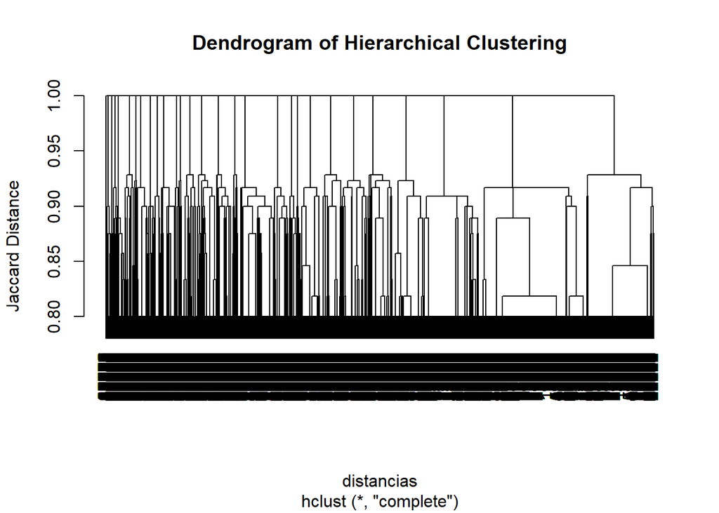

```r
plot(cosas, main = "Dendrogram of Hierarchical Clustering", ylab = "Jaccard Distance", lwd = 1, xlab = NULL)
```

Careful, the it says 0.8, is <=0.8

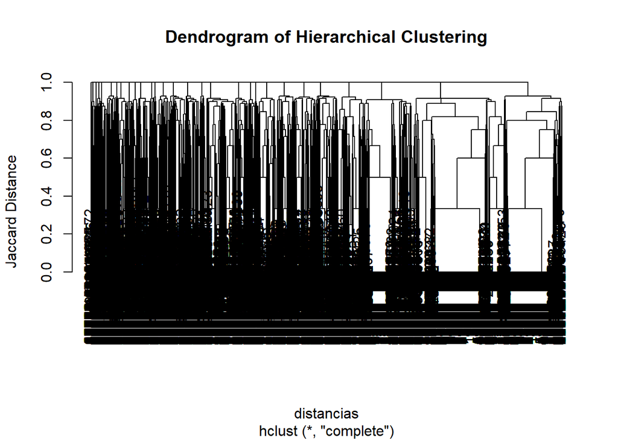

```r
plot(clusters_d, main = "Dendrogram of Hierarchical Clustering", ylab = "Jaccard Distance", lwd = 1, ylim = c(0.8, 1), xlab = NULL)
```

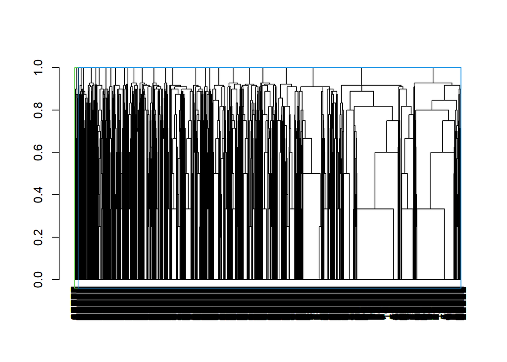

```r
plot(as.dendrogram(clusters_d))
rect.hclust(clusters_d, k = 3, border = 2:6)
```

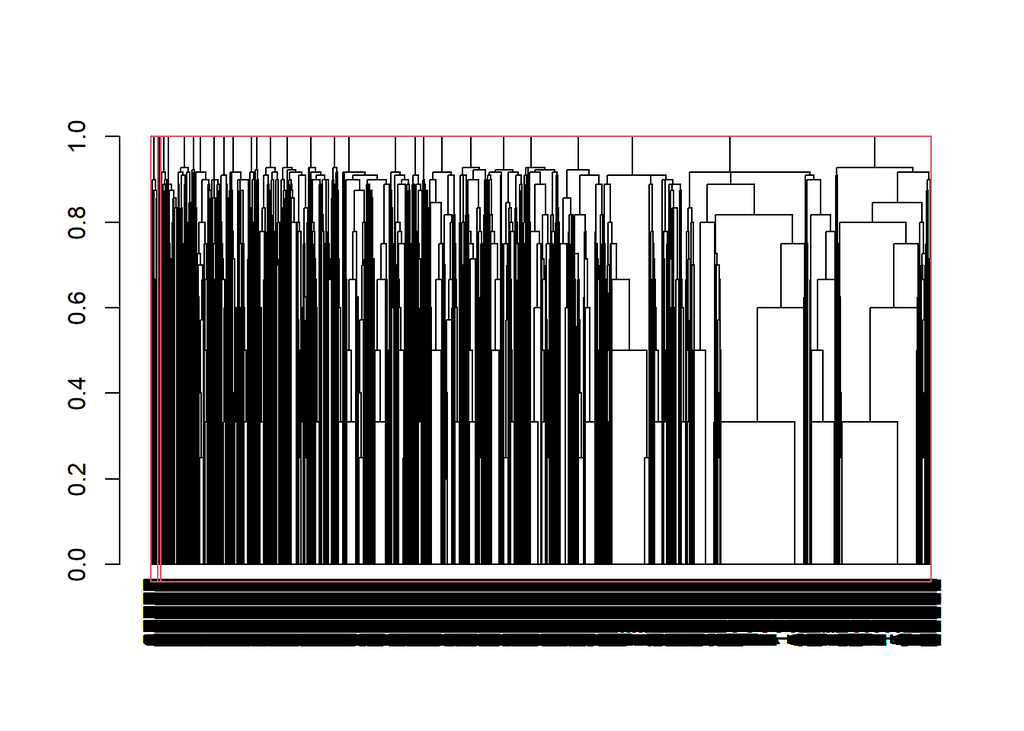

```r
plot(as.dendrogram(clusters_d))
rect.hclust(clusters_d, k = 4)
```

# Stability of HCA partitions that could be created

```r
require(ClustOfVar)
# variable_tree <- hclustvar(X.quali = myMMcondition[,-1])

# estabilidad=ClustOfVar::stability(variable_tree, B = 1000)[["meanCR"]] # vector of mean corrected Rand indices.

# saveRDS(estabilidad, 'estabilidad.RDS')

estabilidad=readRDS('estabilidad.RDS')
```

We created a number of other functions. Please contact Cristina Muntañola if needed.

```r
lsf.str()
```

```
## bootvar : function (X.quanti = NULL, X.quali = NULL)
## clust_diss : function (A, B)
## clusterscore : function (Z)
## fviz_nbclust : function (x, FUNcluster = NULL, method = c("silhouette", "wss", "gap_stat"),
##     diss = NULL, k.max = 10, nboot = 100, verbose = interactive(), barfill = "red",
##     barcolor = "red", linecolor = "red", print.summary = TRUE, ...)
## getnnsvar : function (diss, flag)
## hclustvar : function (X.quanti = NULL, X.quali = NULL, init = NULL)
## rand : function (P, Q, symmetric = TRUE, adj = TRUE)
## stability : function (tree, B = 100, graph = TRUE)
```

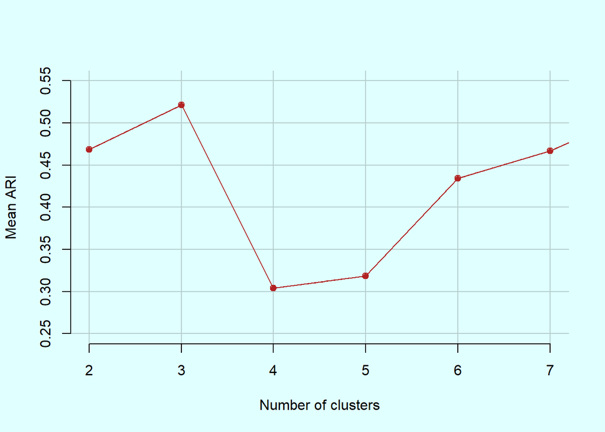

```r
par(bg = '#E0FFFF') # background


estab=data.frame(NCluster=2:(length(unlist(estabilidad))+1), MeanARI=unlist(estabilidad))

plot(estab[1:10,], ylim = c(0.25, 0.55), xlim = c(2, 7), type = "o", cex = 1, axes = FALSE, frame =FALSE, col='firebrick',
     xlab = "Number of clusters", ylab = "Mean ARI", xaxt = "n", yaxt="n", main= NULL,
     panel.first=grid(lty = 1,      # Grid line type
     col = "#B4CDCD", # Grid line color
     lwd = 1))
axis(1)
axis(2)
lines(estab[1:10,], pch = 18, col = "firebrick", type = "o", lty = 2)
```

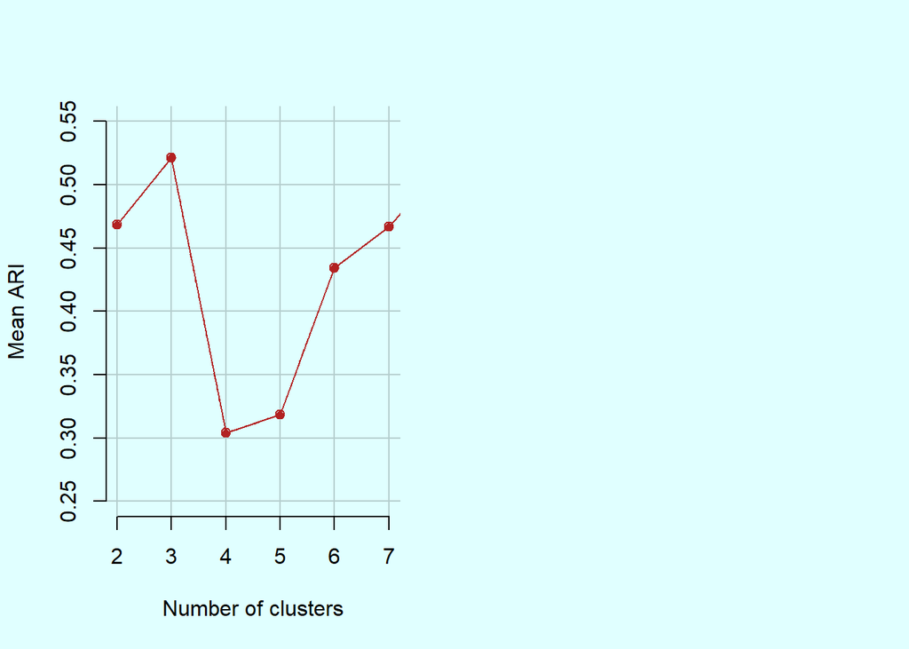

```r
#### same one, but for the paper

par(bg = '#E0FFFF') # background

par(mfrow = c(1, 2))
plot(estab[1:10,], ylim = c(0.25, 0.55), xlim = c(2, 7), type = "o", cex = 1, axes = FALSE, frame =FALSE, col='firebrick',
     xlab = "Number of clusters", ylab = "Mean ARI", xaxt = "n", yaxt="n", main= NULL,
     panel.first=grid(lty = 1,      # Grid line type
     col = "#B4CDCD", # Grid line color
     lwd = 1))
axis(1)
axis(2)
lines(estab[1:10,], pch = 18, col = "firebrick", type = "o", lty = 2)

par(mfrow = c(1, 1))
```

The Rand Index (Rand, 1971) and the Adjusted Rand Index (Yeung & Ruzzo, 2001) are commonly used indices for comparing clustering results against external criteria (Hubert, 1985). (https://doi.org/10.1016/B978-0-12-381972-7.00003-8)

ARI (Adjusted Rand Index) is a corrected version of the Rand index, which measures the degree of overlap between two partitions. The Rand index presents scaling issues, prompting the proposal of a corrected version. While the Rand index ranges from 0 to 1, the ARI can take negative values if the index falls below the expected index value [ 36 ]. Although the ARI can take negative values, its range is generally considered to be [0, 1]. An ARI value of 0 indicates that the actual and modeled groupings do not agree on pairings, while a value of 1 indicates that the actual and modeled groupings represent the same clusters. (https://doi.org/10.1016/bs.adcom.2021.09.008)

In general, the ARI value falls between 0 and 1. The index value equals 1 only if a partition is completely identical to the intrinsic structure, and it is close to 0 for a random partition. (https://doi.org/10.1016/B978-0-12-811654-8.00003-8)

The Rand index calculates the similarity between two clustering results by considering all points identified within the same cluster. This value is 0 when points are randomly assigned to clusters and 1 when the two clustering results are identical [ 27 ]. This metric is used to evaluate whether clustering results based on reduced-dimension similarity are similar to one another. (https://doi.org/10.1016/B978-0-12-805394-2.00015-5)